# Individual fits

# Parameters

An overview of model performance with extreme alpha and beta values.

Large beta is a sign for noisy behavior, flattens the Cronbach alpha measurement.

Small alpha is a sign for no grouping, leads to precise predictions thus no obvious drop of the Cronbash alpha measure as objects vary.

Large alpha and small beta is the most sensitive to the difference of objects in generalization trials, effected by the grouping parameter gamma.

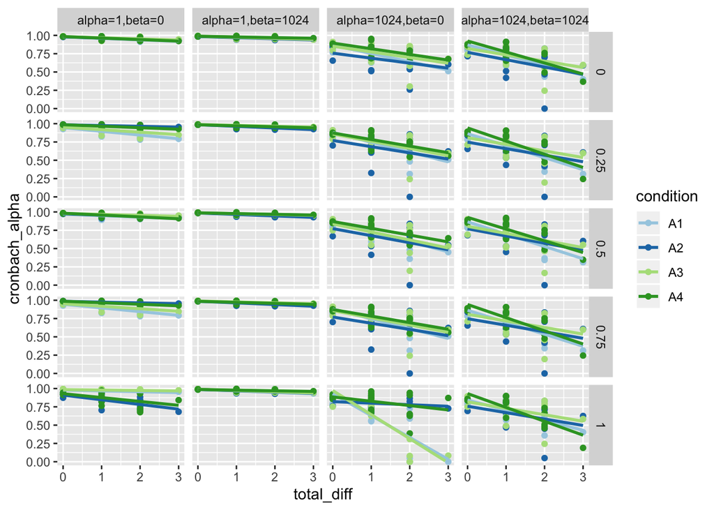

# Individual fits

Let’s have a look at individually-fitted parameters.

## Gamma

Conditions where A is fixed is better fitted by grouping by A (gamma > .5).

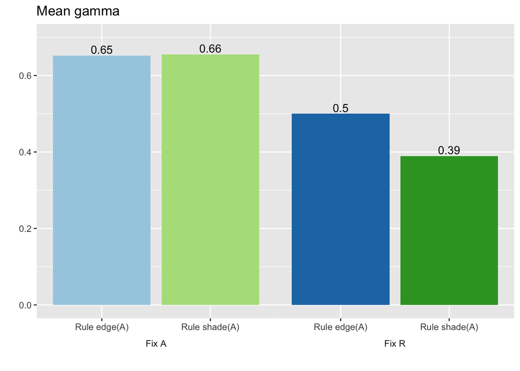

In average, participants that self-reported using categorizations have a higher fitted gamma value.

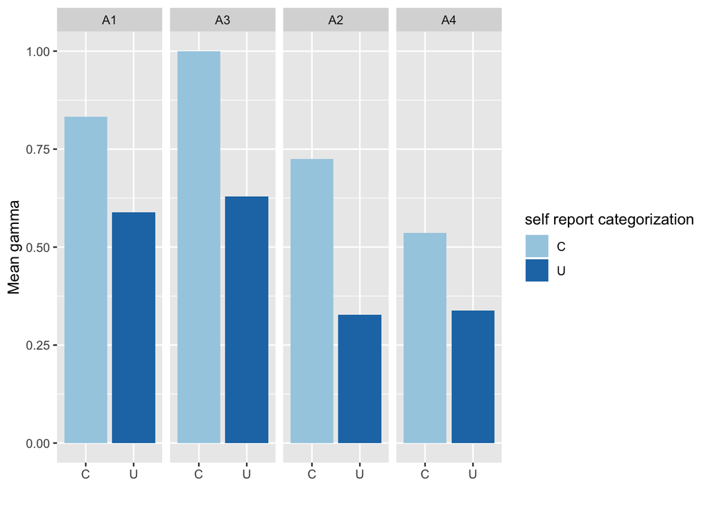

## Alpha

Conditions where A is fixed shows less categorization, inline with self reports.

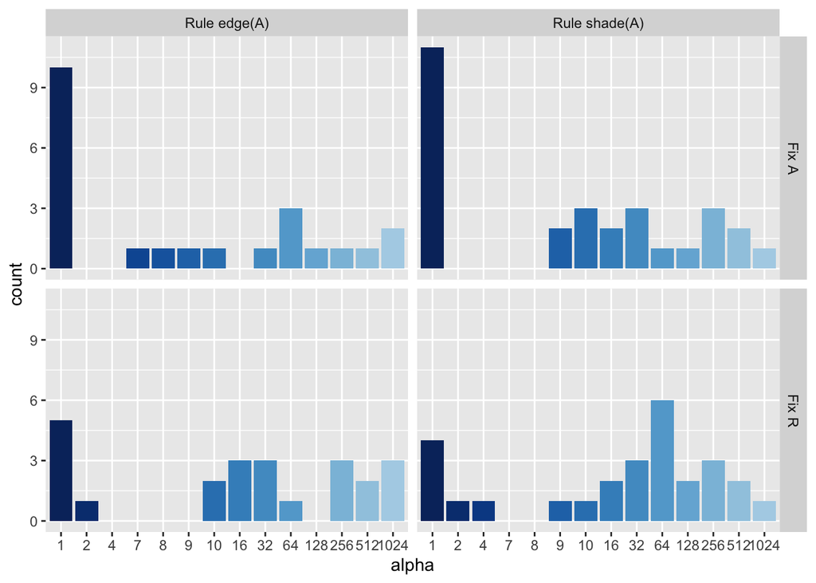

## Beta

The ‘edge(M)=edge(A)+1, shade(M)=shade(R)+1’ conditions have more precise predictions, while participants that are assigned the other rule are more likely to produce noisy predictions.

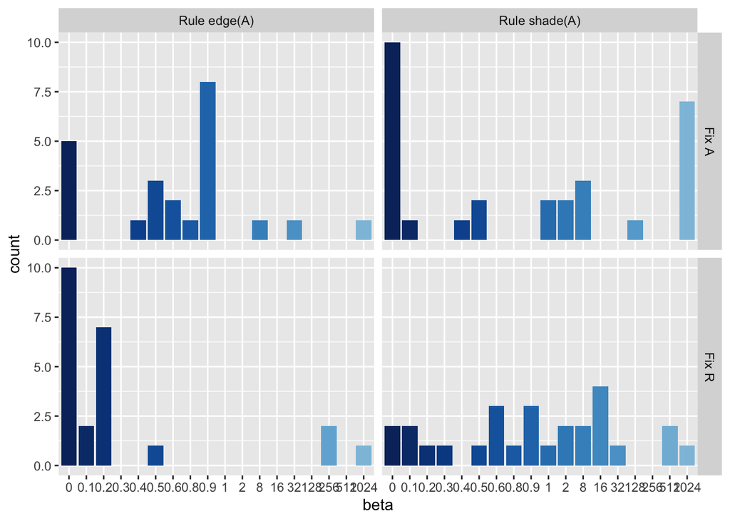

## Overall

In all conditions we found a mixture of best fitted gamma values.

Most individual participants are best fitted by gamma = 0 or 1.

The couple of mixed best-fitted gamma values are only found in conditions where R is fixed.

Conditions where A is fixed have a more concentrated distribution

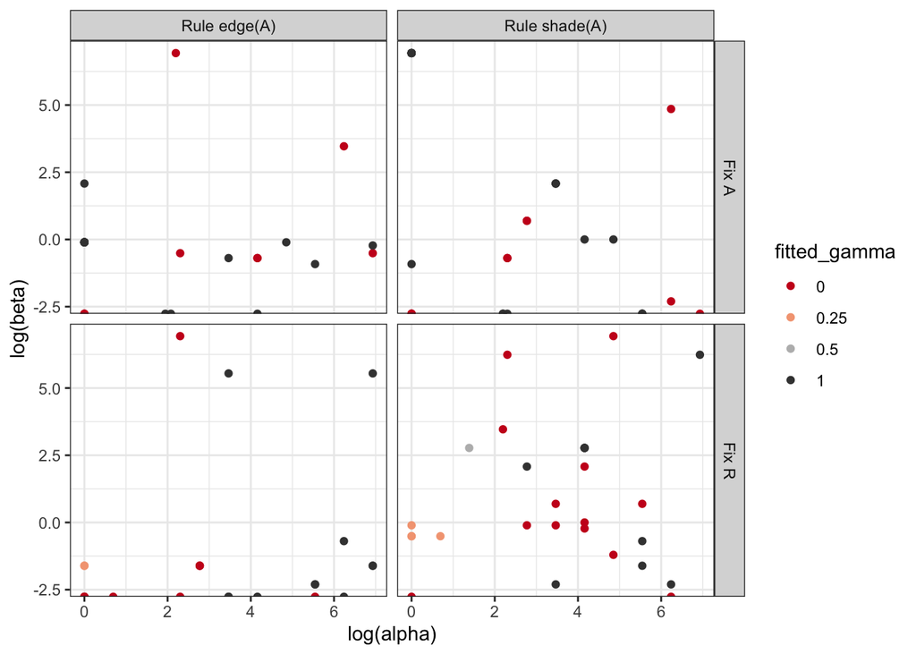

# Sensitivity analysis

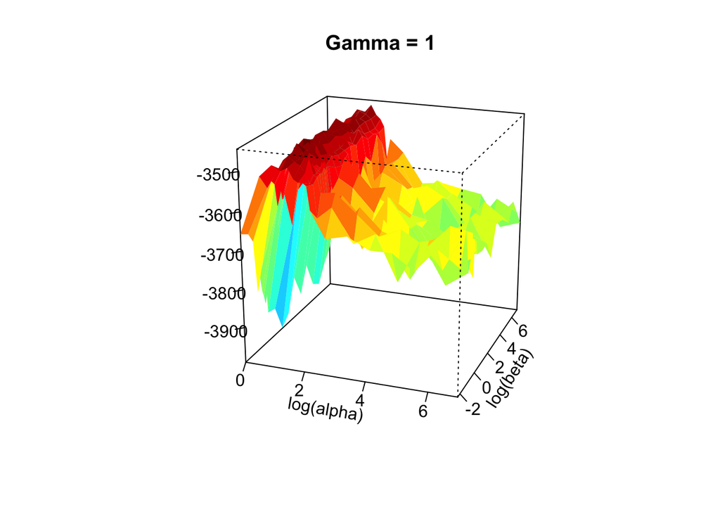

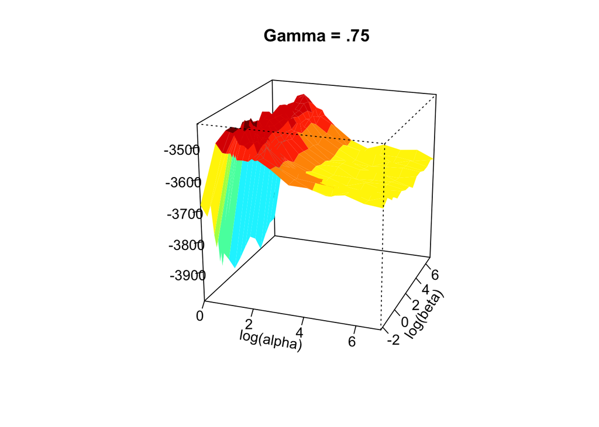

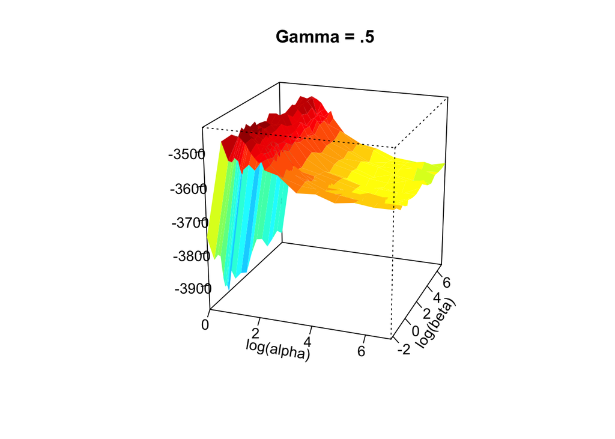

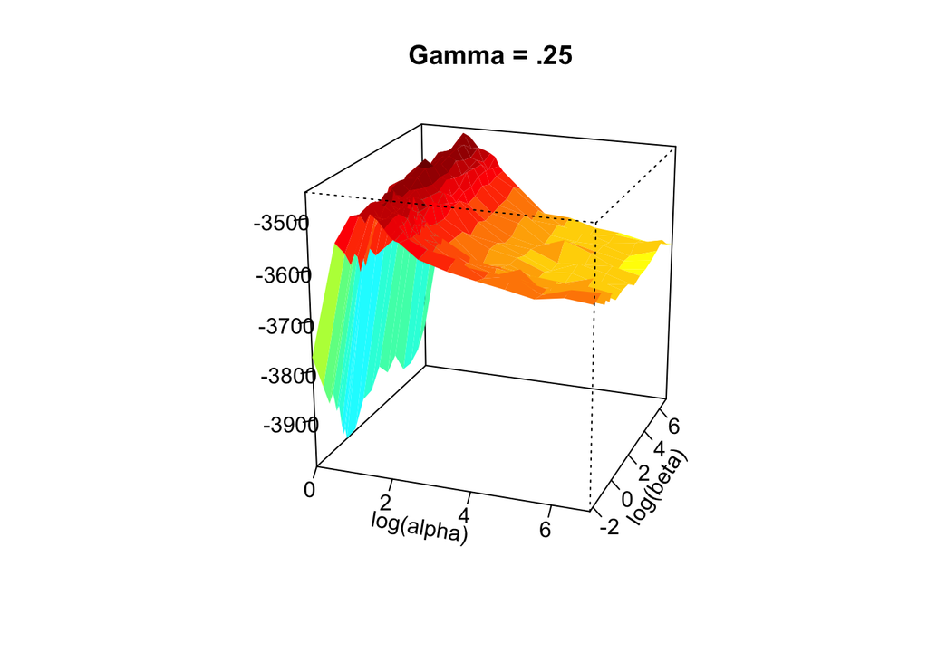

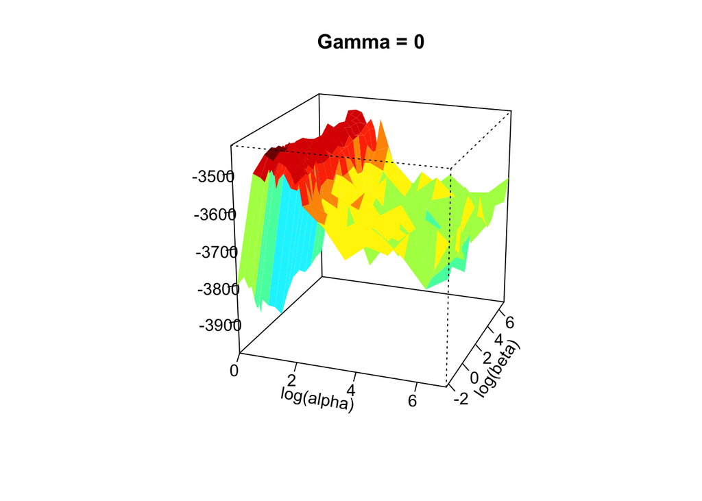